# Project: Wrangling and Analyze Data

```python
import pandas as pd
import numpy as np
import requests
import json
!pip install tweepy
from bs4 import BeautifulSoup
import io
import os
from tweepy import OAuth1UserHandler, API
import tweepy
```

```python
import matplotlib.pyplot as plt
%matplotlib inline
pd.options.display.max_colwidth = 280
```

## Data Gathering

Direct gathering:

```python
#directly downloaded and in the same folder as this notebook, reading into df
df = pd.read_csv('twitter-archive-enhanced.csv')
```

```python
df.shape
```

```
(2356, 17)
```

Requests:

```python
#url obtained in classroom
url = 'https://d17h27t6h515a5.cloudfront.net/topher/2017/August/599fd2ad_image-predictions/image-predictions.tsv'
data = requests.get(url).content
```

```python
#props to https://stackoverflow.com/questions/39213597/convert-text-data-from-requests-object-to-dataframe-with-pandas
df2 = pd.read_csv(io.StringIO(data.decode('utf-8')),sep='\t')
```

Api:

```python
#input keys and call api
#keys removed after retrieveing data from api
auth = OAuth1UserHandler(xxxxxx,xxxxx,xxxxx,xxxxx)
api = API(auth)
api.wait_on_rate_limit=True
api.wait_on_rate_limit_notify=True
```

```python
#delete existing and write to new
if os.path.exists("tweets_json.txt"):
    os.remove("tweets_json.txt")

#create file, loop through our tweet ids, getting the information and writing to the file
#"To query all of the tweet IDs in the WeRateDogs Twitter archive, 20-30 minutes of running time can be expected"
# ^^ i fully understand this now ^^
with open("tweets_json.txt", "a", encoding="utf-8") as file:
    i=0
    for id in df['tweet_id']:
        try:
            tweet = api.get_status(id,tweet_mode='extended')
        except Exception:
            print("deleted tweet")
        converted_json = json.dumps(tweet._json)
        file.write(converted_json)
        file.write('\n')
        print(tweet.id)
        i=i+1
        print("Tweet number", i)
```

[output not shown]

[output cut: 1775 more lines]

[output not shown]

```
Rate limit reached. Sleeping for: 660
```

[output not shown]

[output cut: 1745 more lines]

[output not shown]

```
Rate limit reached. Sleeping for: 674
```

[output not shown]

[output cut: 1057 more lines]

[output not shown]

```python
#reading back line by line and loading to df3
df3 = pd.DataFrame([json.loads(line)
        for line in open('tweets_json.txt', 'r', encoding='utf-8')])
```

## Assessing Data

### Visual Assessment:

```python
df.shape
```

```
(2356, 17)
```

```python
df.sample(5)
```

|  | tweet_id | in_reply_to_status_id | in_reply_to_user_id | timestamp | source | text | retweeted_status_id | retweeted_status_user_id | retweeted_status_timestamp | expanded_urls | rating_numerator | rating_denominator | name | doggo | floofer | pupper | puppo |
| --- | --- | --- | --- | --- | --- | --- | --- | --- | --- | --- | --- | --- | --- | --- | --- | --- | --- |
| 2207 | 668627278264475648 | NaN | NaN | 2015-11-23 03:09:00 +0000 | <a href="http://twitter.com/download/iphone" r... | This is Timofy. He's a pilot for Southwest. It... | NaN | NaN | NaN | https://twitter.com/dog_rates/status/668627278... | 9 | 10 | Timofy | None | None | None | None |
| 386 | 826615380357632002 | NaN | NaN | 2017-02-01 02:17:19 +0000 | <a href="http://twitter.com/download/iphone" r... | RT @dog_rates: Please only send in dogs. We on... | 8.099208e+17 | 4.196984e+09 | 2016-12-17 00:38:52 +0000 | https://twitter.com/dog_rates/status/809920764... | 10 | 10 | None | None | None | None | None |
| 658 | 791672322847637504 | NaN | NaN | 2016-10-27 16:06:04 +0000 | <a href="http://twitter.com/download/iphone" r... | When she says you're a good boy and you know y... | NaN | NaN | NaN | https://twitter.com/dog_rates/status/791672322... | 13 | 10 | None | None | None | None | None |
| 1862 | 675432746517426176 | NaN | NaN | 2015-12-11 21:51:30 +0000 | <a href="http://twitter.com/download/iphone" r... | Happy Friday. Here's some golden puppers. 12/1... | NaN | NaN | NaN | https://twitter.com/dog_rates/status/675432746... | 12 | 10 | None | None | None | None | None |
| 2284 | 667192066997374976 | NaN | NaN | 2015-11-19 04:05:59 +0000 | <a href="http://twitter.com/download/iphone" r... | *takes several long deep breaths* omg omg oMG ... | NaN | NaN | NaN | https://twitter.com/dog_rates/status/667192066... | 12 | 10 | None | None | None | None | None |

```python
df2.shape
```

```
(2075, 12)
```

```python
df2.sample(5)
```

|  | tweet_id | jpg_url | img_num | p1 | p1_conf | p1_dog | p2 | p2_conf | p2_dog | p3 | p3_conf | p3_dog |
| --- | --- | --- | --- | --- | --- | --- | --- | --- | --- | --- | --- | --- |
| 434 | 674372068062928900 | https://pbs.twimg.com/media/CVvZ0KTWwAAdXKV.jpg | 1 | seashore | 0.346126 | False | American_alligator | 0.106404 | False | sandbar | 0.049349 | False |
| 1668 | 813051746834595840 | https://pbs.twimg.com/media/C0iKPZIXUAAbDYV.jpg | 1 | golden_retriever | 0.914804 | True | Labrador_retriever | 0.083550 | True | kuvasz | 0.000453 | True |
| 1197 | 740676976021798912 | https://pbs.twimg.com/media/Ckdpx5KWsAANF6b.jpg | 1 | wombat | 0.462952 | False | Norwegian_elkhound | 0.275225 | True | Siamese_cat | 0.043559 | False |
| 335 | 672205392827572224 | https://pbs.twimg.com/media/CVQnPMrVAAAzShR.jpg | 1 | carton | 0.952613 | False | crate | 0.035376 | False | pug | 0.003267 | True |
| 45 | 666786068205871104 | https://pbs.twimg.com/media/CUDmZIkWcAAIPPe.jpg | 1 | snail | 0.999888 | False | slug | 0.000055 | False | acorn | 0.000026 | False |

```python
#curious on last one from my sample
df[df.tweet_id == 666786068205871104]
```

|  | tweet_id | in_reply_to_status_id | in_reply_to_user_id | timestamp | source | text | retweeted_status_id | retweeted_status_user_id | retweeted_status_timestamp | expanded_urls | rating_numerator | rating_denominator | name | doggo | floofer | pupper | puppo |
| --- | --- | --- | --- | --- | --- | --- | --- | --- | --- | --- | --- | --- | --- | --- | --- | --- | --- |
| 2310 | 666786068205871104 | NaN | NaN | 2015-11-18 01:12:41 +0000 | <a href="http://twitter.com/download/iphone" r... | Unfamiliar with this breed. Ears pointy af. Wo... | NaN | NaN | NaN | https://twitter.com/dog_rates/status/666786068... | 2 | 10 | None | None | None | None | None |

```python
df3.full_text[df3.id == 666786068205871104]
```

```
2310    Unfamiliar with this breed. Ears pointy af. Wo...
Name: full_text, dtype: object
```

```python
df3.sample(5)
```

|  | created_at | id | id_str | full_text | truncated | display_text_range | entities | extended_entities | source | in_reply_to_status_id | ... | favorited | retweeted | possibly_sensitive | possibly_sensitive_appealable | lang | retweeted_status | quoted_status_id | quoted_status_id_str | quoted_status_permalink | quoted_status |
| --- | --- | --- | --- | --- | --- | --- | --- | --- | --- | --- | --- | --- | --- | --- | --- | --- | --- | --- | --- | --- | --- |
| 302 | Tue Feb 28 18:46:45 +0000 2017 | 836648853927522308 | 836648853927522308 | RT @SchafeBacon2016: @dog_rates Slightly distu... | False | [0, 140] | {'hashtags': [], 'symbols': [], 'user_mentions... | NaN | <a href="http://twitter.com/download/iphone" r... | NaN | ... | False | False | NaN | NaN | en | {'created_at': 'Tue Feb 28 18:43:57 +0000 2017... | NaN | NaN | NaN | NaN |
| 1113 | Thu May 19 01:38:16 +0000 2016 | 733109485275860992 | 733109485275860992 | Like father (doggo), like son (pupper). Both 1... | False | [0, 50] | {'hashtags': [], 'symbols': [], 'user_mentions... | {'media': [{'id': 733109473259085826, 'id_str'... | <a href="http://twitter.com/download/iphone" r... | NaN | ... | False | False | False | False | en | NaN | NaN | NaN | NaN | NaN |
| 1667 | Thu Dec 31 20:39:41 +0000 2015 | 682662431982772225 | 682662431982772225 | Meet Joey and Izzy. Joey only has one ear that... | False | [0, 140] | {'hashtags': [], 'symbols': [], 'user_mentions... | {'media': [{'id': 682662408112975876, 'id_str'... | <a href="http://twitter.com/download/iphone" r... | NaN | ... | False | False | False | False | en | NaN | NaN | NaN | NaN | NaN |
| 202 | Sun Apr 16 16:00:07 +0000 2017 | 853639147608842240 | 853639147608842240 | A photographer took pictures before and after ... | False | [0, 108] | {'hashtags': [], 'symbols': [], 'user_mentions... | {'media': [{'id': 853639138628837376, 'id_str'... | <a href="http://twitter.com/download/iphone" r... | NaN | ... | False | False | False | False | en | NaN | NaN | NaN | NaN | NaN |
| 2182 | Tue Nov 24 03:19:43 +0000 2015 | 668992363537309700 | 668992363537309700 | This is Harrison. He braves the snow like a ch... | False | [0, 139] | {'hashtags': [], 'symbols': [], 'user_mentions... | {'media': [{'id': 668992356952199169, 'id_str'... | <a href="http://twitter.com/download/iphone" r... | NaN | ... | False | False | False | False | en | NaN | NaN | NaN | NaN | NaN |

5 rows × 32 columns

```python
list(df), list(df2), list(df3)
```

[output not shown]

### Progmatic Assessment:

```python
df.info()
```

```
<class 'pandas.core.frame.DataFrame'>
RangeIndex: 2356 entries, 0 to 2355
Data columns (total 17 columns):
 #   Column                      Non-Null Count  Dtype
---  ------                      --------------  -----
 0   tweet_id                    2356 non-null   int64
 1   in_reply_to_status_id       78 non-null     float64
 2   in_reply_to_user_id         78 non-null     float64
 3   timestamp                   2356 non-null   object
 4   source                      2356 non-null   object
 5   text                        2356 non-null   object
 6   retweeted_status_id         181 non-null    float64
 7   retweeted_status_user_id    181 non-null    float64
 8   retweeted_status_timestamp  181 non-null    object
 9   expanded_urls               2297 non-null   object
 10  rating_numerator            2356 non-null   int64
 11  rating_denominator          2356 non-null   int64
 12  name                        2356 non-null   object
 13  doggo                       2356 non-null   object
 14  floofer                     2356 non-null   object
 15  pupper                      2356 non-null   object
 16  puppo                       2356 non-null   object
dtypes: float64(4), int64(3), object(10)
memory usage: 313.0+ KB
```

```python
df[['rating_numerator','rating_denominator']].describe()
```

|  | rating_numerator | rating_denominator |
| --- | --- | --- |
| count | 2356.000000 | 2356.000000 |
| mean | 13.126486 | 10.455433 |
| std | 45.876648 | 6.745237 |
| min | 0.000000 | 0.000000 |
| 25% | 10.000000 | 10.000000 |
| 50% | 11.000000 | 10.000000 |
| 75% | 12.000000 | 10.000000 |
| max | 1776.000000 | 170.000000 |

#### Honestly, who rated their dog a 0? This has to be an error

```python
df.rating_numerator.value_counts()
```

```
12      558
11      464
10      461
13      351
9       158
8       102
7        55
14       54
5        37
6        32
3        19
4        17
2         9
1         9
75        2
```

[output cut: 26 more lines]

```python
df.rating_denominator.value_counts()
```

```
10     2333
11        3
50        3
20        2
80        2
70        1
7         1
15        1
150       1
170       1
0         1
90        1
40        1
130       1
110       1
16        1
120       1
2         1
Name: rating_denominator, dtype: int64
```

```python
df[df.rating_denominator != 10]
```

|  | tweet_id | in_reply_to_status_id | in_reply_to_user_id | timestamp | source | text | retweeted_status_id | retweeted_status_user_id | retweeted_status_timestamp | expanded_urls | rating_numerator | rating_denominator | name | doggo | floofer | pupper | puppo |
| --- | --- | --- | --- | --- | --- | --- | --- | --- | --- | --- | --- | --- | --- | --- | --- | --- | --- |
| 313 | 835246439529840640 | 8.352460e+17 | 2.625958e+07 | 2017-02-24 21:54:03 +0000 | <a href="http://twitter.com/download/iphone" r... | @jonnysun @Lin_Manuel ok jomny I know you're e... | NaN | NaN | NaN | NaN | 960 | 0 | None | None | None | None | None |
| 342 | 832088576586297345 | 8.320875e+17 | 3.058208e+07 | 2017-02-16 04:45:50 +0000 | <a href="http://twitter.com/download/iphone" r... | @docmisterio account started on 11/15/15 | NaN | NaN | NaN | NaN | 11 | 15 | None | None | None | None | None |
| 433 | 820690176645140481 | NaN | NaN | 2017-01-15 17:52:40 +0000 | <a href="http://twitter.com/download/iphone" r... | The floofs have been released I repeat the flo... | NaN | NaN | NaN | https://twitter.com/dog_rates/status/820690176... | 84 | 70 | None | None | None | None | None |
| 516 | 810984652412424192 | NaN | NaN | 2016-12-19 23:06:23 +0000 | <a href="http://twitter.com/download/iphone" r... | Meet Sam. She smiles 24/7 &amp; secretly aspir... | NaN | NaN | NaN | https://www.gofundme.com/sams-smile,https://tw... | 24 | 7 | Sam | None | None | None | None |
| 784 | 775096608509886464 | NaN | NaN | 2016-09-11 22:20:06 +0000 | <a href="http://twitter.com/download/iphone" r... | RT @dog_rates: After so many requests, this is... | 7.403732e+17 | 4.196984e+09 | 2016-06-08 02:41:38 +0000 | https://twitter.com/dog_rates/status/740373189... | 9 | 11 | None | None | None | None | None |
| 902 | 758467244762497024 | NaN | NaN | 2016-07-28 01:00:57 +0000 | <a href="http://twitter.com/download/iphone" r... | Why does this never happen at my front door...... | NaN | NaN | NaN | https://twitter.com/dog_rates/status/758467244... | 165 | 150 | None | None | None | None | None |
| 1068 | 740373189193256964 | NaN | NaN | 2016-06-08 02:41:38 +0000 | <a href="http://twitter.com/download/iphone" r... | After so many requests, this is Bretagne. She ... | NaN | NaN | NaN | https://twitter.com/dog_rates/status/740373189... | 9 | 11 | None | None | None | None | None |
| 1120 | 731156023742988288 | NaN | NaN | 2016-05-13 16:15:54 +0000 | <a href="http://twitter.com/download/iphone" r... | Say hello to this unbelievably well behaved sq... | NaN | NaN | NaN | https://twitter.com/dog_rates/status/731156023... | 204 | 170 | this | None | None | None | None |
| 1165 | 722974582966214656 | NaN | NaN | 2016-04-21 02:25:47 +0000 | <a href="http://twitter.com/download/iphone" r... | Happy 4/20 from the squad! 13/10 for all https... | NaN | NaN | NaN | https://twitter.com/dog_rates/status/722974582... | 4 | 20 | None | None | None | None | None |
| 1202 | 716439118184652801 | NaN | NaN | 2016-04-03 01:36:11 +0000 | <a href="http://twitter.com/download/iphone" r... | This is Bluebert. He just saw that both #Final... | NaN | NaN | NaN | https://twitter.com/dog_rates/status/716439118... | 50 | 50 | Bluebert | None | None | None | None |
| 1228 | 713900603437621249 | NaN | NaN | 2016-03-27 01:29:02 +0000 | <a href="http://twitter.com/download/iphone" r... | Happy Saturday here's 9 puppers on a bench. 99... | NaN | NaN | NaN | https://twitter.com/dog_rates/status/713900603... | 99 | 90 | None | None | None | None | None |
| 1254 | 710658690886586372 | NaN | NaN | 2016-03-18 02:46:49 +0000 | <a href="http://twitter.com/download/iphone" r... | Here's a brigade of puppers. All look very pre... | NaN | NaN | NaN | https://twitter.com/dog_rates/status/710658690... | 80 | 80 | None | None | None | None | None |
| 1274 | 709198395643068416 | NaN | NaN | 2016-03-14 02:04:08 +0000 | <a href="http://twitter.com/download/iphone" r... | From left to right:\nCletus, Jerome, Alejandro... | NaN | NaN | NaN | https://twitter.com/dog_rates/status/709198395... | 45 | 50 | None | None | None | None | None |
| 1351 | 704054845121142784 | NaN | NaN | 2016-02-28 21:25:30 +0000 | <a href="http://twitter.com/download/iphone" r... | Here is a whole flock of puppers. 60/50 I'll ... | NaN | NaN | NaN | https://twitter.com/dog_rates/status/704054845... | 60 | 50 | a | None | None | None | None |
| 1433 | 697463031882764288 | NaN | NaN | 2016-02-10 16:51:59 +0000 | <a href="http://twitter.com/download/iphone" r... | Happy Wednesday here's a bucket of pups. 44/40... | NaN | NaN | NaN | https://twitter.com/dog_rates/status/697463031... | 44 | 40 | None | None | None | None | None |
| 1598 | 686035780142297088 | 6.860340e+17 | 4.196984e+09 | 2016-01-10 04:04:10 +0000 | <a href="http://twitter.com/download/iphone" r... | Yes I do realize a rating of 4/20 would've bee... | NaN | NaN | NaN | NaN | 4 | 20 | None | None | None | None | None |
| 1634 | 684225744407494656 | 6.842229e+17 | 4.196984e+09 | 2016-01-05 04:11:44 +0000 | <a href="http://twitter.com/download/iphone" r... | Two sneaky puppers were not initially seen, mo... | NaN | NaN | NaN | https://twitter.com/dog_rates/status/684225744... | 143 | 130 | None | None | None | None | None |
| 1635 | 684222868335505415 | NaN | NaN | 2016-01-05 04:00:18 +0000 | <a href="http://twitter.com/download/iphone" r... | Someone help the girl is being mugged. Several... | NaN | NaN | NaN | https://twitter.com/dog_rates/status/684222868... | 121 | 110 | None | None | None | None | None |
| 1662 | 682962037429899265 | NaN | NaN | 2016-01-01 16:30:13 +0000 | <a href="http://twitter.com/download/iphone" r... | This is Darrel. He just robbed a 7/11 and is i... | NaN | NaN | NaN | https://twitter.com/dog_rates/status/682962037... | 7 | 11 | Darrel | None | None | None | None |
| 1663 | 682808988178739200 | 6.827884e+17 | 4.196984e+09 | 2016-01-01 06:22:03 +0000 | <a href="http://twitter.com/download/iphone" r... | I'm aware that I could've said 20/16, but here... | NaN | NaN | NaN | NaN | 20 | 16 | None | None | None | None | None |
| 1779 | 677716515794329600 | NaN | NaN | 2015-12-18 05:06:23 +0000 | <a href="http://twitter.com/download/iphone" r... | IT'S PUPPERGEDDON. Total of 144/120 ...I think... | NaN | NaN | NaN | https://twitter.com/dog_rates/status/677716515... | 144 | 120 | None | None | None | None | None |
| 1843 | 675853064436391936 | NaN | NaN | 2015-12-13 01:41:41 +0000 | <a href="http://twitter.com/download/iphone" r... | Here we have an entire platoon of puppers. Tot... | NaN | NaN | NaN | https://twitter.com/dog_rates/status/675853064... | 88 | 80 | None | None | None | None | None |
| 2335 | 666287406224695296 | NaN | NaN | 2015-11-16 16:11:11 +0000 | <a href="http://twitter.com/download/iphone" r... | This is an Albanian 3 1/2 legged Episcopalian... | NaN | NaN | NaN | https://twitter.com/dog_rates/status/666287406... | 1 | 2 | an | None | None | None | None |

```python
df3.full_text[df3.id == 835246439529840640]
```

```
313    @jonnysun @Lin_Manuel ok jomny I know you're excited but 960/00 isn't a valid rating, 13/10 is tho
Name: full_text, dtype: object
```

Also, we don't want to work with 0 in a denominator.

```python
df2.info()
```

```
<class 'pandas.core.frame.DataFrame'>
RangeIndex: 2075 entries, 0 to 2074
Data columns (total 12 columns):
 #   Column    Non-Null Count  Dtype
---  ------    --------------  -----
 0   tweet_id  2075 non-null   int64
 1   jpg_url   2075 non-null   object
 2   img_num   2075 non-null   int64
 3   p1        2075 non-null   object
 4   p1_conf   2075 non-null   float64
 5   p1_dog    2075 non-null   bool
 6   p2        2075 non-null   object
 7   p2_conf   2075 non-null   float64
 8   p2_dog    2075 non-null   bool
 9   p3        2075 non-null   object
 10  p3_conf   2075 non-null   float64
 11  p3_dog    2075 non-null   bool
dtypes: bool(3), float64(3), int64(2), object(4)
memory usage: 152.1+ KB
```

```python
df3.info()
```

```
<class 'pandas.core.frame.DataFrame'>
RangeIndex: 2356 entries, 0 to 2355
Data columns (total 32 columns):
 #   Column                         Non-Null Count  Dtype
---  ------                         --------------  -----
 0   created_at                     2356 non-null   object
 1   id                             2356 non-null   int64
 2   id_str                         2356 non-null   object
 3   full_text                      2356 non-null   object
 4   truncated                      2356 non-null   bool
 5   display_text_range             2356 non-null   object
 6   entities                       2356 non-null   object
 7   extended_entities              2083 non-null   object
 8   source                         2356 non-null   object
 9   in_reply_to_status_id          79 non-null     float64
```

[output cut: 24 more lines]

```python
df3.truncated.value_counts()
```

```
False    2356
Name: truncated, dtype: int64
```

```python
df3.lang.value_counts()
```

```
en     2338
und       7
in        3
nl        3
eu        1
es        1
tl        1
ro        1
et        1
Name: lang, dtype: int64
```

```python
all_columns = pd.Series(list(df) + list(df2) + list(df3))
all_columns[all_columns.duplicated()]
```

```
17                 tweet_id
37                   source
38    in_reply_to_status_id
40      in_reply_to_user_id
dtype: object
```

### Quality issues

1. Gofundme 24/7 interpreted as rating 24/7
2. Dividing by 0
3. Some tweets not in English
4. Retweets to remove
5. Some Ratings too high
6. Timestamp not in date time
7. Some images in df2 are not of dogs
8. text is truncated in df
9. Ratings = 0

### Tidiness issues

1. Id and Id_str extracted from api
2. Duplicated columns between tables

## Cleaning Data

```python
# Making copies of original pieces of data
download_df = df.copy()
get_df = df2.copy()
api_df = df3.copy()
```

### Issue #1:

#### Define:

When tweets were extracted fom api, it came with id and id_str. we shall keep the id column because it matches our tweet_id from df, which shall be used later to join the df's.

#### Code

```python
api_df.drop(columns=('id_str'),axis=1,inplace=True)
```

#### Test

```python
api_df.head()
```

|  | created_at | id | full_text | truncated | display_text_range | entities | extended_entities | source | in_reply_to_status_id | in_reply_to_status_id_str | ... | favorited | retweeted | possibly_sensitive | possibly_sensitive_appealable | lang | retweeted_status | quoted_status_id | quoted_status_id_str | quoted_status_permalink | quoted_status |
| --- | --- | --- | --- | --- | --- | --- | --- | --- | --- | --- | --- | --- | --- | --- | --- | --- | --- | --- | --- | --- | --- |
| 0 | Tue Aug 01 16:23:56 +0000 2017 | 892420643555336193 | This is Phineas. He's a mystical boy. Only ever appears in the hole of a donut. 13/10 https://t.co/MgUWQ76dJU | False | [0, 85] | {'hashtags': [], 'symbols': [], 'user_mentions': [], 'urls': [], 'media': [{'id': 892420639486877696, 'id_str': '892420639486877696', 'indices': [86, 109], 'media_url': 'http://pbs.twimg.com/media/DGK… | {'media': [{'id': 892420639486877696, 'id_str': '892420639486877696', 'indices': [86, 109], 'media_url': 'http://pbs.twimg.com/media/DGKD1-bXoAAIAUK.jpg', 'media_url_https': 'https://pbs.twimg.com/med… | <a href="http://twitter.com/download/iphone" rel="nofollow">Twitter for iPhone</a> | NaN | None | ... | False | False | False | False | en | NaN | NaN | NaN | NaN | NaN |
| 1 | Tue Aug 01 00:17:27 +0000 2017 | 892177421306343426 | This is Tilly. She's just checking pup on you. Hopes you're doing ok. If not, she's available for pats, snugs, boops, the whole bit. 13/10 https://t.co/0Xxu71qeIV | False | [0, 138] | {'hashtags': [], 'symbols': [], 'user_mentions': [], 'urls': [], 'media': [{'id': 892177413194625024, 'id_str': '892177413194625024', 'indices': [139, 162], 'media_url': 'http://pbs.twimg.com/media/DG… | {'media': [{'id': 892177413194625024, 'id_str': '892177413194625024', 'indices': [139, 162], 'media_url': 'http://pbs.twimg.com/media/DGGmoV4XsAAUL6n.jpg', 'media_url_https': 'https://pbs.twimg.com/me… | <a href="http://twitter.com/download/iphone" rel="nofollow">Twitter for iPhone</a> | NaN | None | ... | False | False | False | False | en | NaN | NaN | NaN | NaN | NaN |
| 2 | Mon Jul 31 00:18:03 +0000 2017 | 891815181378084864 | This is Archie. He is a rare Norwegian Pouncing Corgo. Lives in the tall grass. You never know when one may strike. 12/10 https://t.co/wUnZnhtVJB | False | [0, 121] | {'hashtags': [], 'symbols': [], 'user_mentions': [], 'urls': [], 'media': [{'id': 891815175371796480, 'id_str': '891815175371796480', 'indices': [122, 145], 'media_url': 'http://pbs.twimg.com/media/DG… | {'media': [{'id': 891815175371796480, 'id_str': '891815175371796480', 'indices': [122, 145], 'media_url': 'http://pbs.twimg.com/media/DGBdLU1WsAANxJ9.jpg', 'media_url_https': 'https://pbs.twimg.com/me… | <a href="http://twitter.com/download/iphone" rel="nofollow">Twitter for iPhone</a> | NaN | None | ... | False | False | False | False | en | NaN | NaN | NaN | NaN | NaN |
| 3 | Sun Jul 30 15:58:51 +0000 2017 | 891689557279858688 | This is Darla. She commenced a snooze mid meal. 13/10 happens to the best of us https://t.co/tD36da7qLQ | False | [0, 79] | {'hashtags': [], 'symbols': [], 'user_mentions': [], 'urls': [], 'media': [{'id': 891689552724799489, 'id_str': '891689552724799489', 'indices': [80, 103], 'media_url': 'http://pbs.twimg.com/media/DF_… | {'media': [{'id': 891689552724799489, 'id_str': '891689552724799489', 'indices': [80, 103], 'media_url': 'http://pbs.twimg.com/media/DF_q7IAWsAEuuN8.jpg', 'media_url_https': 'https://pbs.twimg.com/med… | <a href="http://twitter.com/download/iphone" rel="nofollow">Twitter for iPhone</a> | NaN | None | ... | False | False | False | False | en | NaN | NaN | NaN | NaN | NaN |
| 4 | Sat Jul 29 16:00:24 +0000 2017 | 891327558926688256 | This is Franklin. He would like you to stop calling him "cute." He is a very fierce shark and should be respected as such. 12/10 #BarkWeek https://t.co/AtUZn91f7f | False | [0, 138] | {'hashtags': [{'text': 'BarkWeek', 'indices': [129, 138]}], 'symbols': [], 'user_mentions': [], 'urls': [], 'media': [{'id': 891327551943041024, 'id_str': '891327551943041024', 'indices': [139, 162], … | {'media': [{'id': 891327551943041024, 'id_str': '891327551943041024', 'indices': [139, 162], 'media_url': 'http://pbs.twimg.com/media/DF6hr6AVYAAZ8G8.jpg', 'media_url_https': 'https://pbs.twimg.com/me… | <a href="http://twitter.com/download/iphone" rel="nofollow">Twitter for iPhone</a> | NaN | None | ... | False | False | False | False | en | NaN | NaN | NaN | NaN | NaN |

5 rows × 31 columns

### Issue #2:

#### Define

A lot of duplicate information pulled from the downloaded data file and the Api. Shall remove so we don't have redundant information. Along with information that is not needed

#### Code

```python
api_df.drop(columns={'in_reply_to_status_id','in_reply_to_user_id','source'},axis=1,inplace=True)
```

#### Test

```python
api_df.head()
```

|  | created_at | id | full_text | truncated | display_text_range | entities | extended_entities | in_reply_to_status_id_str | in_reply_to_user_id_str | in_reply_to_screen_name | ... | favorited | retweeted | possibly_sensitive | possibly_sensitive_appealable | lang | retweeted_status | quoted_status_id | quoted_status_id_str | quoted_status_permalink | quoted_status |
| --- | --- | --- | --- | --- | --- | --- | --- | --- | --- | --- | --- | --- | --- | --- | --- | --- | --- | --- | --- | --- | --- |
| 0 | Tue Aug 01 16:23:56 +0000 2017 | 892420643555336193 | This is Phineas. He's a mystical boy. Only ever appears in the hole of a donut. 13/10 https://t.co/MgUWQ76dJU | False | [0, 85] | {'hashtags': [], 'symbols': [], 'user_mentions': [], 'urls': [], 'media': [{'id': 892420639486877696, 'id_str': '892420639486877696', 'indices': [86, 109], 'media_url': 'http://pbs.twimg.com/media/DGK… | {'media': [{'id': 892420639486877696, 'id_str': '892420639486877696', 'indices': [86, 109], 'media_url': 'http://pbs.twimg.com/media/DGKD1-bXoAAIAUK.jpg', 'media_url_https': 'https://pbs.twimg.com/med… | None | None | None | ... | False | False | False | False | en | NaN | NaN | NaN | NaN | NaN |
| 1 | Tue Aug 01 00:17:27 +0000 2017 | 892177421306343426 | This is Tilly. She's just checking pup on you. Hopes you're doing ok. If not, she's available for pats, snugs, boops, the whole bit. 13/10 https://t.co/0Xxu71qeIV | False | [0, 138] | {'hashtags': [], 'symbols': [], 'user_mentions': [], 'urls': [], 'media': [{'id': 892177413194625024, 'id_str': '892177413194625024', 'indices': [139, 162], 'media_url': 'http://pbs.twimg.com/media/DG… | {'media': [{'id': 892177413194625024, 'id_str': '892177413194625024', 'indices': [139, 162], 'media_url': 'http://pbs.twimg.com/media/DGGmoV4XsAAUL6n.jpg', 'media_url_https': 'https://pbs.twimg.com/me… | None | None | None | ... | False | False | False | False | en | NaN | NaN | NaN | NaN | NaN |
| 2 | Mon Jul 31 00:18:03 +0000 2017 | 891815181378084864 | This is Archie. He is a rare Norwegian Pouncing Corgo. Lives in the tall grass. You never know when one may strike. 12/10 https://t.co/wUnZnhtVJB | False | [0, 121] | {'hashtags': [], 'symbols': [], 'user_mentions': [], 'urls': [], 'media': [{'id': 891815175371796480, 'id_str': '891815175371796480', 'indices': [122, 145], 'media_url': 'http://pbs.twimg.com/media/DG… | {'media': [{'id': 891815175371796480, 'id_str': '891815175371796480', 'indices': [122, 145], 'media_url': 'http://pbs.twimg.com/media/DGBdLU1WsAANxJ9.jpg', 'media_url_https': 'https://pbs.twimg.com/me… | None | None | None | ... | False | False | False | False | en | NaN | NaN | NaN | NaN | NaN |
| 3 | Sun Jul 30 15:58:51 +0000 2017 | 891689557279858688 | This is Darla. She commenced a snooze mid meal. 13/10 happens to the best of us https://t.co/tD36da7qLQ | False | [0, 79] | {'hashtags': [], 'symbols': [], 'user_mentions': [], 'urls': [], 'media': [{'id': 891689552724799489, 'id_str': '891689552724799489', 'indices': [80, 103], 'media_url': 'http://pbs.twimg.com/media/DF_… | {'media': [{'id': 891689552724799489, 'id_str': '891689552724799489', 'indices': [80, 103], 'media_url': 'http://pbs.twimg.com/media/DF_q7IAWsAEuuN8.jpg', 'media_url_https': 'https://pbs.twimg.com/med… | None | None | None | ... | False | False | False | False | en | NaN | NaN | NaN | NaN | NaN |
| 4 | Sat Jul 29 16:00:24 +0000 2017 | 891327558926688256 | This is Franklin. He would like you to stop calling him "cute." He is a very fierce shark and should be respected as such. 12/10 #BarkWeek https://t.co/AtUZn91f7f | False | [0, 138] | {'hashtags': [{'text': 'BarkWeek', 'indices': [129, 138]}], 'symbols': [], 'user_mentions': [], 'urls': [], 'media': [{'id': 891327551943041024, 'id_str': '891327551943041024', 'indices': [139, 162], … | {'media': [{'id': 891327551943041024, 'id_str': '891327551943041024', 'indices': [139, 162], 'media_url': 'http://pbs.twimg.com/media/DF6hr6AVYAAZ8G8.jpg', 'media_url_https': 'https://pbs.twimg.com/me… | None | None | None | ... | False | False | False | False | en | NaN | NaN | NaN | NaN | NaN |

5 rows × 28 columns

```python
all_columns = pd.Series(list(download_df) + list(get_df) + list(api_df))
all_columns[all_columns.duplicated()]
```

```
17    tweet_id
dtype: object
```

### Issue #1

#### Define: Gofundme interpreted 24/7 as a rating, further investigation to see what can be done to possibly correct this issue

#### Code:

```python
download_df[download_df.rating_numerator == 24]
```

|  | tweet_id | in_reply_to_status_id | in_reply_to_user_id | timestamp | source | text | retweeted_status_id | retweeted_status_user_id | retweeted_status_timestamp | expanded_urls | rating_numerator | rating_denominator | name | doggo | floofer | pupper | puppo |
| --- | --- | --- | --- | --- | --- | --- | --- | --- | --- | --- | --- | --- | --- | --- | --- | --- | --- |
| 516 | 810984652412424192 | NaN | NaN | 2016-12-19 23:06:23 +0000 | <a href="http://twitter.com/download/iphone" rel="nofollow">Twitter for iPhone</a> | Meet Sam. She smiles 24/7 &amp; secretly aspires to be a reindeer. \nKeep Sam smiling by clicking and sharing this link:\nhttps://t.co/98tB8y7y7t https://t.co/LouL5vdvxx | NaN | NaN | NaN | https://www.gofundme.com/sams-smile,https://twitter.com/dog_rates/status/810984652412424192/photo/1 | 24 | 7 | Sam | None | None | None | None |

```python
api_df[api_df.id == 810984652412424192].full_text
```

```
516    Meet Sam. She smiles 24/7 &amp; secretly aspires to be a reindeer. \nKeep Sam smiling by clicking and sharing this link:\nhttps://t.co/98tB8y7y7t https://t.co/LouL5vdvxx
Name: full_text, dtype: object
```

Apparently this tweet does not contain a rating so unfortunately for Sam, she will have to go.

```python
download_df = download_df.drop(labels=516,axis=0)
```

#### Test:

```python
download_df[download_df.tweet_id == 810984652412424192]
```

|  | tweet_id | in_reply_to_status_id | in_reply_to_user_id | timestamp | source | text | retweeted_status_id | retweeted_status_user_id | retweeted_status_timestamp | expanded_urls | rating_numerator | rating_denominator | name | doggo | floofer | pupper | puppo |
| --- | --- | --- | --- | --- | --- | --- | --- | --- | --- | --- | --- | --- | --- | --- | --- | --- | --- |

### Issue #2

#### Define: Tweets not in english

#### Code:

```python
api_df = api_df.query('lang == "en"')
```

#### Test:

```python
api_df.lang.value_counts()
```

```
en    2338
Name: lang, dtype: int64
```

```python
#comparision of original
df3.lang.value_counts()
```

```
en     2338
und       7
in        3
nl        3
eu        1
es        1
tl        1
ro        1
et        1
Name: lang, dtype: int64
```

### Issue #3

#### Define: Need to remove retweets

```python
download_df.retweeted_status_id.value_counts().count()
```

```
181
```

#### Code:

```python
#for api_df
api_df = api_df[api_df.in_reply_to_screen_name.isnull() == True]
#for download_df
download_df = download_df[download_df.retweeted_status_id.isnull() == True]
```

#### Test:

```python
#should be empty, so no retweets
api_df.in_reply_to_screen_name.value_counts(), download_df.retweeted_status_id.value_counts()
```

```
(Series([], Name: in_reply_to_screen_name, dtype: int64),
 Series([], Name: retweeted_status_id, dtype: int64))
```

### Issue #4

#### Define: Ratings too high and abnormal Denominators

For the purpose of making our visualizations better, i am going to limit to ratings up to 20 in the numerator and only those wtih 10 in denominator

#### Code:

```python
download_df.rating_numerator.describe()
```

```
count    2174.000000
mean       13.210212
std        47.736116
min         0.000000
25%        10.000000
50%        11.000000
75%        12.000000
max      1776.000000
Name: rating_numerator, dtype: float64
```

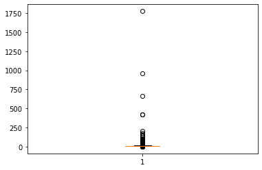

```python
plt.boxplot(download_df.rating_numerator);
#thats a lot of outliers...
```

```python
#saving only the filtered part of the Df
download_df = download_df[download_df.rating_numerator <= 20]
```

```python
download_df.rating_denominator.value_counts()
```

```
10    2145
11       2
20       2
15       1
16       1
2        1
Name: rating_denominator, dtype: int64
```

```python
#Once again only saving the filtered part of the Df
download_df = download_df[download_df.rating_denominator == 10]
```

#### Test:

```python
download_df.rating_denominator.describe()
```

```
count    2145.0
mean       10.0
std         0.0
min        10.0
25%        10.0
50%        10.0
75%        10.0
max        10.0
Name: rating_denominator, dtype: float64
```

```python
download_df.rating_numerator.describe()
```

```
count    2145.000000
mean       10.621911
std         2.199301
min         0.000000
25%        10.000000
50%        11.000000
75%        12.000000
max        17.000000
Name: rating_numerator, dtype: float64
```

### Issue #5

#### Define: Timestamp not in datetime

#### Code:

```python
download_df.timestamp = pd.to_datetime(download_df.timestamp)
```

#### Test:

```python
download_df.info()
```

```
<class 'pandas.core.frame.DataFrame'>
Int64Index: 2145 entries, 0 to 2355
Data columns (total 17 columns):
 #   Column                      Non-Null Count  Dtype
---  ------                      --------------  -----
 0   tweet_id                    2145 non-null   int64
 1   in_reply_to_status_id       70 non-null     float64
 2   in_reply_to_user_id         70 non-null     float64
 3   timestamp                   2145 non-null   datetime64[ns, UTC]
 4   source                      2145 non-null   object
 5   text                        2145 non-null   object
 6   retweeted_status_id         0 non-null      float64
 7   retweeted_status_user_id    0 non-null      float64
 8   retweeted_status_timestamp  0 non-null      object
 9   expanded_urls               2094 non-null   object
 10  rating_numerator            2145 non-null   int64
 11  rating_denominator          2145 non-null   int64
 12  name                        2145 non-null   object
 13  doggo                       2145 non-null   object
 14  floofer                     2145 non-null   object
 15  pupper                      2145 non-null   object
 16  puppo                       2145 non-null   object
dtypes: datetime64[ns, UTC](1), float64(4), int64(3), object(9)
memory usage: 301.6+ KB
```

### Issue #6

#### Define: Some images in get_df not of dogs

#### Code:

```python
#since our pX_dog column is type bool, we can sum up the 3 and choose only the ones that have at least 1 True
#this will be useful later to eliminate the tweets that don't contain dogs from our final analysis
get_df = get_df[(get_df.p1_dog + get_df.p2_dog + get_df.p3_dog) == True]
```

#### Test:

```python
get_df.shape
```

```
(1751, 12)
```

```python
#comparing with the original df2
df2.shape
```

```
(2075, 12)
```

### Issue #7

#### Define: Ratings at 0

Let's investigate further why we have some ratings at 0

#### Code:

```python
download_df[download_df.rating_numerator == 0].text
```

```
315           When you're so blinded by your systematic plagiarism that you forget what day it is. 0/10 https://t.co/YbEJPkg4Ag
1016    PUPDATE: can't see any. Even if I could, I couldn't reach them to pet. 0/10 much disappointment https://t.co/c7WXaB2nqX
Name: text, dtype: object
```

After further investigation, i have concluded that one deserved to be rated 0 because it was a repost. Reposting is not cool. The other post was a picture of a skyline, no dog = not in our data, goodbye!

```python
download_df = download_df.drop(labels=[315,1016],axis=0)
```

#### Test:

```python
download_df[download_df.rating_numerator == 0]
```

|  | tweet_id | in_reply_to_status_id | in_reply_to_user_id | timestamp | source | text | retweeted_status_id | retweeted_status_user_id | retweeted_status_timestamp | expanded_urls | rating_numerator | rating_denominator | name | doggo | floofer | pupper | puppo |
| --- | --- | --- | --- | --- | --- | --- | --- | --- | --- | --- | --- | --- | --- | --- | --- | --- | --- |

### Issue #8

#### Define: Text is truncated in download_df

#### Code:

```python
#setting the display option to the same size as tweet max
#since i retrieved from api with mode 'extended', i'm gonna drop the text from the download_df and keep the full_text from api_df
pd.options.display.max_colwidth = 280
download_df.drop(columns=('text'),axis=1,inplace=True)
```

#### Test:

```python
download_df.head()
```

|  | tweet_id | in_reply_to_status_id | in_reply_to_user_id | timestamp | source | retweeted_status_id | retweeted_status_user_id | retweeted_status_timestamp | expanded_urls | rating_numerator | rating_denominator | name | doggo | floofer | pupper | puppo |
| --- | --- | --- | --- | --- | --- | --- | --- | --- | --- | --- | --- | --- | --- | --- | --- | --- |
| 0 | 892420643555336193 | NaN | NaN | 2017-08-01 16:23:56+00:00 | <a href="http://twitter.com/download/iphone" rel="nofollow">Twitter for iPhone</a> | NaN | NaN | NaN | https://twitter.com/dog_rates/status/892420643555336193/photo/1 | 13 | 10 | Phineas | None | None | None | None |
| 1 | 892177421306343426 | NaN | NaN | 2017-08-01 00:17:27+00:00 | <a href="http://twitter.com/download/iphone" rel="nofollow">Twitter for iPhone</a> | NaN | NaN | NaN | https://twitter.com/dog_rates/status/892177421306343426/photo/1 | 13 | 10 | Tilly | None | None | None | None |
| 2 | 891815181378084864 | NaN | NaN | 2017-07-31 00:18:03+00:00 | <a href="http://twitter.com/download/iphone" rel="nofollow">Twitter for iPhone</a> | NaN | NaN | NaN | https://twitter.com/dog_rates/status/891815181378084864/photo/1 | 12 | 10 | Archie | None | None | None | None |
| 3 | 891689557279858688 | NaN | NaN | 2017-07-30 15:58:51+00:00 | <a href="http://twitter.com/download/iphone" rel="nofollow">Twitter for iPhone</a> | NaN | NaN | NaN | https://twitter.com/dog_rates/status/891689557279858688/photo/1 | 13 | 10 | Darla | None | None | None | None |
| 4 | 891327558926688256 | NaN | NaN | 2017-07-29 16:00:24+00:00 | <a href="http://twitter.com/download/iphone" rel="nofollow">Twitter for iPhone</a> | NaN | NaN | NaN | https://twitter.com/dog_rates/status/891327558926688256/photo/1,https://twitter.com/dog_rates/status/891327558926688256/photo/1 | 12 | 10 | Franklin | None | None | None | None |

## Storing Data

Now that we have removed all the not dog pictures and weird ratings, time to put all our df's together to produce some nice visuals. Going to have to drop a lot of columns and do some inner joins

```python
api_df.rename(columns={'id':'tweet_id'},inplace=True)
```

```python
Masterdf = pd.merge(download_df,get_df,on='tweet_id',how='inner')
Masterdf = pd.merge(Masterdf,api_df,on='tweet_id',how='inner')
```

```python
#Time for the manual labor of removing all the columns we don't want
Masterdf.info()
```

```
<class 'pandas.core.frame.DataFrame'>
Int64Index: 1656 entries, 0 to 1655
Data columns (total 54 columns):
 #   Column                         Non-Null Count  Dtype
---  ------                         --------------  -----
 0   tweet_id                       1656 non-null   int64
 1   in_reply_to_status_id          0 non-null      float64
 2   in_reply_to_user_id            0 non-null      float64
 3   timestamp                      1656 non-null   datetime64[ns, UTC]
 4   source                         1656 non-null   object
 5   retweeted_status_id            0 non-null      float64
 6   retweeted_status_user_id       0 non-null      float64
 7   retweeted_status_timestamp     0 non-null      object
 8   expanded_urls                  1656 non-null   object
 9   rating_numerator               1656 non-null   int64
```

[output cut: 46 more lines]

```python
#dropping empty columns
Masterdf.dropna(axis=1,inplace=True)

#dropping columns we dont need
Masterdf.drop(Masterdf.columns[[2,3,22,24,25,26,27,28,29,32,33,34,35,36]],axis=1,inplace=True)

#Since we normalized the denominator to 10, we can just drop that column too
Masterdf.drop(columns=('rating_denominator'),axis=1,inplace=True)

#renaming rating
Masterdf.rename(columns={'rating_numerator':'rating'},inplace=True)

Masterdf.to_csv('twitter_archive_master.csv')
```

```python
Masterdf.info()
```

```
<class 'pandas.core.frame.DataFrame'>
Int64Index: 1656 entries, 0 to 1655
Data columns (total 22 columns):
 #   Column          Non-Null Count  Dtype
---  ------          --------------  -----
 0   tweet_id        1656 non-null   int64
 1   timestamp       1656 non-null   datetime64[ns, UTC]
 2   rating          1656 non-null   int64
 3   name            1656 non-null   object
 4   doggo           1656 non-null   object
 5   floofer         1656 non-null   object
 6   pupper          1656 non-null   object
 7   puppo           1656 non-null   object
 8   jpg_url         1656 non-null   object
 9   img_num         1656 non-null   int64
 10  p1              1656 non-null   object
 11  p1_conf         1656 non-null   float64
 12  p1_dog          1656 non-null   bool
 13  p2              1656 non-null   object
 14  p2_conf         1656 non-null   float64
 15  p2_dog          1656 non-null   bool
 16  p3              1656 non-null   object
 17  p3_conf         1656 non-null   float64
 18  p3_dog          1656 non-null   bool
 19  full_text       1656 non-null   object
 20  retweet_count   1656 non-null   int64
 21  favorite_count  1656 non-null   int64
dtypes: bool(3), datetime64[ns, UTC](1), float64(3), int64(5), object(10)
memory usage: 263.6+ KB
```

```python
#great, now we have a Master df with just tweets of dogs,
#with normalized denominators, not so outrageous ratings, not retweets and in english, looks good
Masterdf.head()
```

|  | tweet_id | timestamp | rating | name | doggo | floofer | pupper | puppo | jpg_url | img_num | ... | p1_dog | p2 | p2_conf | p2_dog | p3 | p3_conf | p3_dog | full_text | retweet_count | favorite_count |
| --- | --- | --- | --- | --- | --- | --- | --- | --- | --- | --- | --- | --- | --- | --- | --- | --- | --- | --- | --- | --- | --- |
| 0 | 892177421306343426 | 2017-08-01 00:17:27+00:00 | 13 | Tilly | None | None | None | None | https://pbs.twimg.com/media/DGGmoV4XsAAUL6n.jpg | 1 | ... | True | Pekinese | 0.090647 | True | papillon | 0.068957 | True | This is Tilly. She's just checking pup on you. Hopes you're doing ok. If not, she's available for pats, snugs, boops, the whole bit. 13/10 https://t.co/0Xxu71qeIV | 5272 | 29222 |
| 1 | 891815181378084864 | 2017-07-31 00:18:03+00:00 | 12 | Archie | None | None | None | None | https://pbs.twimg.com/media/DGBdLU1WsAANxJ9.jpg | 1 | ... | True | malamute | 0.078253 | True | kelpie | 0.031379 | True | This is Archie. He is a rare Norwegian Pouncing Corgo. Lives in the tall grass. You never know when one may strike. 12/10 https://t.co/wUnZnhtVJB | 3464 | 21978 |
| 2 | 891689557279858688 | 2017-07-30 15:58:51+00:00 | 13 | Darla | None | None | None | None | https://pbs.twimg.com/media/DF_q7IAWsAEuuN8.jpg | 1 | ... | False | Labrador_retriever | 0.168086 | True | spatula | 0.040836 | False | This is Darla. She commenced a snooze mid meal. 13/10 happens to the best of us https://t.co/tD36da7qLQ | 7191 | 36791 |
| 3 | 891327558926688256 | 2017-07-29 16:00:24+00:00 | 12 | Franklin | None | None | None | None | https://pbs.twimg.com/media/DF6hr6BUMAAzZgT.jpg | 2 | ... | True | English_springer | 0.225770 | True | German_short-haired_pointer | 0.175219 | True | This is Franklin. He would like you to stop calling him "cute." He is a very fierce shark and should be respected as such. 12/10 #BarkWeek https://t.co/AtUZn91f7f | 7717 | 35182 |
| 4 | 891087950875897856 | 2017-07-29 00:08:17+00:00 | 13 | None | None | None | None | None | https://pbs.twimg.com/media/DF3HwyEWsAABqE6.jpg | 1 | ... | True | Irish_terrier | 0.116317 | True | Indian_elephant | 0.076902 | False | Here we have a majestic great white breaching off South Africa's coast. Absolutely h*ckin breathtaking. 13/10 (IG: tucker_marlo) #BarkWeek https://t.co/kQ04fDDRmh | 2586 | 17749 |

5 rows × 22 columns

## Analyzing and Visualizing Data

Now time to analyze. I wonder if we find any correlations between type of dog (doggo, puppo, pupper or fluff) and their ratings. Maybe even correlate rating with amount of likes and upvotes. Lastly, if our data from the neural network can correlate confidence with amount of likes (i.e pictures that don't identify well as dogs (low confidence values) don't attract likes.

```python
pupper = Masterdf[Masterdf.pupper == "pupper"]
puppo = Masterdf[Masterdf.puppo == "puppo"]
doggo = Masterdf[Masterdf.doggo == "doggo"]
floofer = Masterdf[Masterdf.floofer == "floofer"]
```

```python
pupper.rating.describe() , puppo.rating.describe() , doggo.rating.describe(), floofer.rating.describe()
```

```
(count    174.000000
 mean      10.896552
 std        1.482339
 min        5.000000
 25%       10.000000
 50%       11.000000
 75%       12.000000
 max       14.000000
 Name: rating, dtype: float64,
 count    23.000000
 mean     12.043478
 std       1.296087
 min       9.000000
 25%      11.500000
 50%      12.000000
 75%      13.000000
 max      14.000000
 Name: rating, dtype: float64,
 count    64.000000
 mean     11.812500
 std       1.552008
 min       5.000000
 25%      11.000000
 50%      12.000000
 75%      13.000000
 max      14.000000
 Name: rating, dtype: float64,
 count     8.000000
 mean     11.875000
 std       1.125992
 min      10.000000
 25%      11.000000
 50%      12.000000
 75%      13.000000
 max      13.000000
 Name: rating, dtype: float64)
```

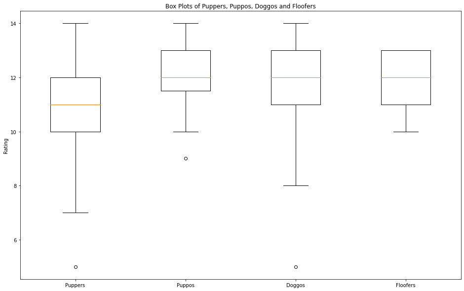

```python
data = (pupper.rating,puppo.rating,doggo.rating,floofer.rating)
fig, ax = plt.subplots()
ax.boxplot(data)
plt.title("Box Plots of Puppers, Puppos, Doggos and Floofers")
ax.set_xticklabels(("Puppers","Puppos","Doggos","Floofers"))
plt.ylabel("Rating")
plt.show()
```

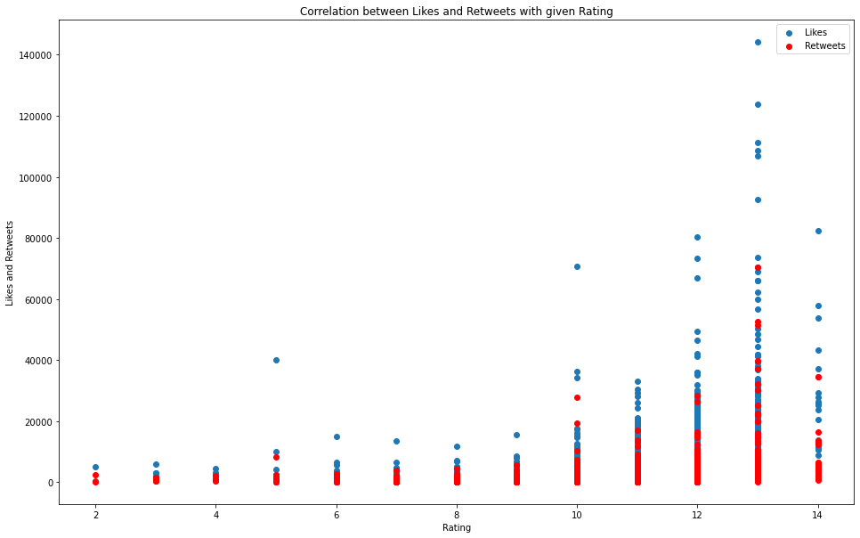

```python
#plotting Likes+Retweets vs Rating to try and see correlation
plt.scatter(Masterdf.rating,Masterdf.favorite_count)
plt.scatter(Masterdf.rating,Masterdf.retweet_count,color='r')
plt.title("Correlation between Likes and Retweets with given Rating")
plt.xlabel("Rating")
plt.ylabel("Likes and Retweets")
plt.legend(("Likes","Retweets"));
```

```python
#Separating our masterdf between images that were recognized in p1 , p2 or p3 as dogs
p1_t = Masterdf[Masterdf.p1_dog == True]
p2_t = Masterdf[(Masterdf.p1_dog == False) & (Masterdf.p2_dog == True)]
p3_t = Masterdf[(Masterdf.p1_dog == False) & (Masterdf.p2_dog == False) & (Masterdf.p3_dog == True)]
```

```python
p1_t.favorite_count.mean(), p2_t.favorite_count.mean(), p3_t.favorite_count.mean()
```

```
(8198.0557467309, 7972.625, 7720.152542372882)
```

```python
p1_t.retweet_count.mean(), p2_t.retweet_count.mean(), p3_t.retweet_count.mean()
```

```
(2287.392980041294, 2462.9513888888887, 2520.7118644067796)
```

### Insights:

1. Although somewhat insignificant, Puppos have a slightly higher rating compared to other dog types, average rating 12.04.
2. Likes and Retweets correlate positively with a dogs given rating, with the sweet spot being the traditional "13/10"
3. Images that were better identified as dogs by the neural network translated to tweets with more likes BUT images that were hard to identify as a dog had more retweets!

### Visualization

```python
!pip install pillow
!pip install wordcloud
from PIL import Image
from wordcloud import WordCloud, STOPWORDS, ImageColorGenerator
```

```python
Wordcloud_df = []
Wordcloud_df = pd.merge(pupper,puppo,how='outer')
Wordcloud_df = pd.merge(floofer,doggo,how='outer')
Wordcloud_df = pd.merge(Wordcloud_df,floofer,how='outer')
```

```python
#Image take myself on my trip last year to jackson hole while visiting Yellow Stone National Park
#stopwords to not count some basic words and make our wordcloud more meaningful

text = " ".join(cat for cat in Wordcloud_df.full_text)
list_stopwords = ('https','t','co','This','is','a','in','She','He','would','to','the','and','for','of','you','with','amp')
mask = np.array(Image.open("goodboi_mask.png"))
word_cloud = WordCloud(
        width=3000,
        height=2000,
        random_state=1,
        background_color="white",
        collocations=False,
        stopwords=list_stopwords,
        mask=mask,
        margin=5,
        contour_color='steelblue',
        max_words=150
        )

word_cloud.generate(text)

word_cloud.to_file('Dog_word_cloud.png');
```

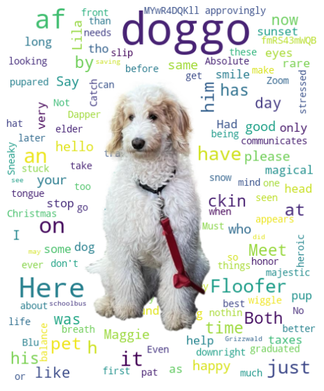

```python
plt.imshow(word_cloud,interpolation='bilinear')
plt.axis("off")
plt.imshow(mask, cmap=plt.cm.gray, interpolation='bilinear')
plt.axis("off")
plt.show()
```